First, let us load the data and necessary packages:

```r
load("ames_train.Rdata")
library(MASS)
library(dplyr)
```

```r
library(ggplot2)
library(devtools)
library(statsr)
library(BAS)
```

1. Make a labeled histogram (with 30 bins) of the ages of the houses in the data set, and describe the distribution.

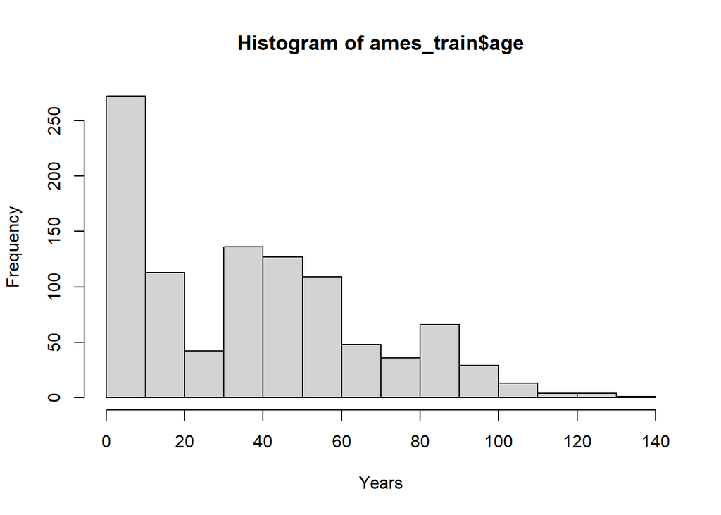

```r
ames_train$age <- 2010-ames_train$Year.Built
hist(ames_train$age, xlab = "Years")
```

2. The mantra in real estate is “Location, Location, Location!” Make a graphical display that relates a home price to its neighborhood in Ames, Iowa. Which summary statistics are most appropriate to use for determining the most expensive, least expensive, and most heterogeneous (having the most variation in housing price) neighborhoods? Report which neighborhoods these are based on the summary statistics of your choice. Report the value of your chosen summary statistics for these neighborhoods.

```r
ames_loc <- ames_train %>%
  dplyr::select(price, Neighborhood) %>%
  group_by(Neighborhood) %>%
  summarise(median = median(price), max = max(price), min = min(price), sd = sd(price))
print(arrange(ames_loc, desc(median)))
```

```
## # A tibble: 27 x 5
##    Neighborhood  median    max    min      sd
##    <fct>          <dbl>  <int>  <int>   <dbl>
##  1 StoneBr      340692. 591587 180000 123459.
##  2 NridgHt      336860  615000 173000 105089.
##  3 NoRidge      290000  405000 235000  35889.
##  4 GrnHill      280000  330000 230000  70711.
##  5 Timber       232500  425000 175000  84030.
##  6 Somerst      221650  468000 139000  65199.
##  7 Greens       212625  214000 155000  29063.
##  8 Veenker      205750  385000 150000  72545.
##  9 Crawfor      205000  392500  96500  71268.
## 10 CollgCr      195800  475000 110000  52786.
## # ... with 17 more rows
```

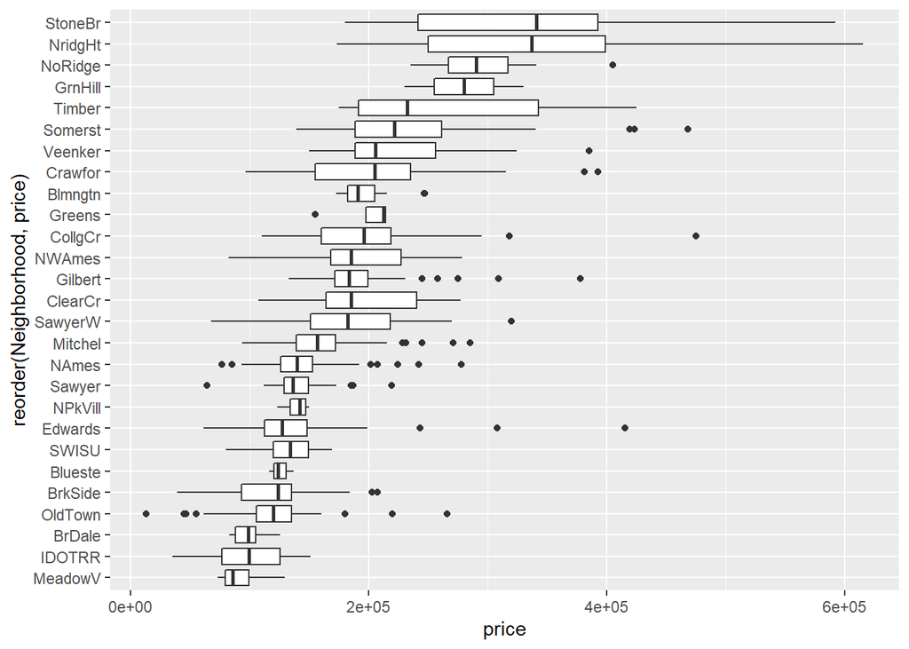

```r
ggplot(ames_train, aes(y = price, x = reorder(Neighborhood, price)), main = "Price among Neighborhoods", xlim= "Neighborhood", ylim="Price" )+geom_boxplot() + coord_flip()
```

3. Which variable has the largest number of missing values? Explain why it makes sense that there are so many missing values for this variable.

```r
sort(colSums(is.na(ames_train)), decreasing=TRUE)
```

```
##         Pool.QC    Misc.Feature           Alley           Fence    Fireplace.Qu
##             997             971             933             798             491
##    Lot.Frontage   Garage.Yr.Blt     Garage.Qual     Garage.Cond     Garage.Type
##             167              48              47              47              46
##   Garage.Finish       Bsmt.Qual       Bsmt.Cond   Bsmt.Exposure  BsmtFin.Type.1
##              46              21              21              21              21
##  BsmtFin.Type.2    Mas.Vnr.Area    BsmtFin.SF.1    BsmtFin.SF.2     Bsmt.Unf.SF
##              21               7               1               1               1
##   Total.Bsmt.SF  Bsmt.Full.Bath  Bsmt.Half.Bath     Garage.Cars     Garage.Area
##               1               1               1               1               1
##             PID            area           price     MS.SubClass       MS.Zoning
##               0               0               0               0               0
##        Lot.Area          Street       Lot.Shape    Land.Contour       Utilities
##               0               0               0               0               0
##      Lot.Config      Land.Slope    Neighborhood     Condition.1     Condition.2
##               0               0               0               0               0
##       Bldg.Type     House.Style    Overall.Qual    Overall.Cond      Year.Built
##               0               0               0               0               0
##  Year.Remod.Add      Roof.Style       Roof.Matl    Exterior.1st    Exterior.2nd
##               0               0               0               0               0
##    Mas.Vnr.Type      Exter.Qual      Exter.Cond      Foundation         Heating
##               0               0               0               0               0
##      Heating.QC     Central.Air      Electrical     X1st.Flr.SF     X2nd.Flr.SF
##               0               0               0               0               0
## Low.Qual.Fin.SF       Full.Bath       Half.Bath   Bedroom.AbvGr   Kitchen.AbvGr
##               0               0               0               0               0
##    Kitchen.Qual   TotRms.AbvGrd      Functional      Fireplaces     Paved.Drive
##               0               0               0               0               0
##    Wood.Deck.SF   Open.Porch.SF  Enclosed.Porch     X3Ssn.Porch    Screen.Porch
##               0               0               0               0               0
##       Pool.Area        Misc.Val         Mo.Sold         Yr.Sold       Sale.Type
##               0               0               0               0               0
##  Sale.Condition             age
##               0               0
```

Pool.QC has the largest number of missing values. This variable represents pool area and, as well as, that simply shows that a lot of houses do not have a pool

4. We want to predict the natural log of the home prices. Candidate explanatory variables are lot size in square feet (Lot.Area), slope of property (Land.Slope), original construction date (Year.Built), remodel date (Year.Remod.Add), and the number of bedrooms above grade (Bedroom.AbvGr). Pick a model selection or model averaging method covered in the Specialization, and describe how this method works. Then, use this method to find the best multiple regression model for predicting the natural log of the home prices.

```r
fit_lm = lm(log(price) ~ Lot.Area + Land.Slope + Year.Built + Year.Remod.Add + Bedroom.AbvGr,
            data = ames_train)
summary(fit_lm)
```

```
##
## Call:
## lm(formula = log(price) ~ Lot.Area + Land.Slope + Year.Built +
##     Year.Remod.Add + Bedroom.AbvGr, data = ames_train)
##
## Residuals:
##     Min      1Q  Median      3Q     Max
## -2.0878 -0.1651 -0.0211  0.1657  0.9945
##
## Coefficients:
##                  Estimate Std. Error t value Pr(>|t|)
## (Intercept)    -1.371e+01  8.574e-01 -15.996  < 2e-16 ***
## Lot.Area        1.028e-05  1.106e-06   9.296  < 2e-16 ***
## Land.SlopeMod   1.384e-01  4.991e-02   2.773  0.00565 **
## Land.SlopeSev  -4.567e-01  1.514e-01  -3.016  0.00263 **
## Year.Built      6.049e-03  3.788e-04  15.968  < 2e-16 ***
## Year.Remod.Add  6.778e-03  5.468e-04  12.395  < 2e-16 ***
## Bedroom.AbvGr   8.686e-02  1.077e-02   8.063 2.12e-15 ***
## ---
## Signif. codes:  0 '***' 0.001 '**' 0.01 '*' 0.05 '.' 0.1 ' ' 1
##
## Residual standard error: 0.279 on 993 degrees of freedom
## Multiple R-squared:  0.5625, Adjusted R-squared:  0.5598
## F-statistic: 212.8 on 6 and 993 DF,  p-value: < 2.2e-16
```

```r
fit_bic = bas.lm(log(price) ~ Lot.Area + Land.Slope + Year.Built + Year.Remod.Add + Bedroom.AbvGr,
                 data = ames_train,
                 prior = "BIC",
                 modelprior = uniform(),
                 method = "MCMC" )
summary(fit_bic)
```

```
##                P(B != 0 | Y)    model 1       model 2      model 3
## Intercept          1.0000000     1.0000     1.0000000     1.000000
## Lot.Area           0.9953125     1.0000     1.0000000     1.000000
## Land.SlopeMod      0.6179687     1.0000     0.0000000     1.000000
## Land.SlopeSev      0.8148437     1.0000     1.0000000     0.000000
## Year.Built         0.9992188     1.0000     1.0000000     1.000000
## Year.Remod.Add     0.9929687     1.0000     1.0000000     1.000000
## Bedroom.AbvGr      0.9968750     1.0000     1.0000000     1.000000
## BF                        NA     1.0000     0.6674353     0.330911
## PostProbs                 NA     0.4590     0.3552000     0.153000
## R2                        NA     0.5625     0.5591000     0.558500
## dim                       NA     7.0000     6.0000000     6.000000
## logmarg                   NA -2198.1673 -2198.5716571 -2199.273250
##                      model 4       model 5
## Intercept          1.0000000  1.000000e+00
## Lot.Area           1.0000000  1.000000e+00
## Land.SlopeMod      0.0000000  1.000000e+00
## Land.SlopeSev      0.0000000  0.000000e+00
## Year.Built         1.0000000  1.000000e+00
## Year.Remod.Add     1.0000000  0.000000e+00
## Bedroom.AbvGr      1.0000000  1.000000e+00
## BF                 0.1061955  1.885595e-31
## PostProbs          0.0250000  2.300000e-03
## R2                 0.5544000  4.890000e-01
## dim                5.0000000  5.000000e+00
## logmarg        -2200.4098178 -2.268913e+03
```

A way to work around the problem with choosing the right model is to implement Bayesian model averaging (BMA), in which several models are averaged to produce posterior coefficient values and predictions based on new data. For the model, pre-distribution is selected and BIC is selected as the pre-distribution. To calculate the probability of the model, we use the Markov Monte Carlo chain. (MCMC) In addition, BIC chooses simpler models than AIC. Thus, from the current BMA (BIC and MCMC), we can see that the model proposes to keep all the variables as the most appropriate predictors of house prices.

5. Which home has the largest squared residual in the previous analysis (Question 4)? Looking at all the variables in the data set, can you explain why this home stands out from the rest (what factors contribute to the high squared residual and why are those factors relevant)?

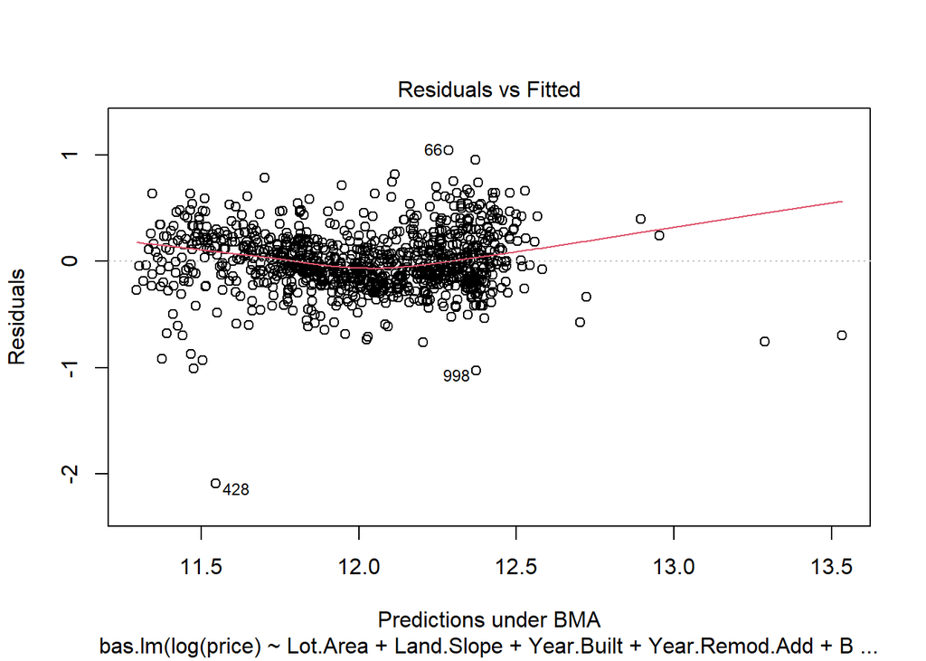

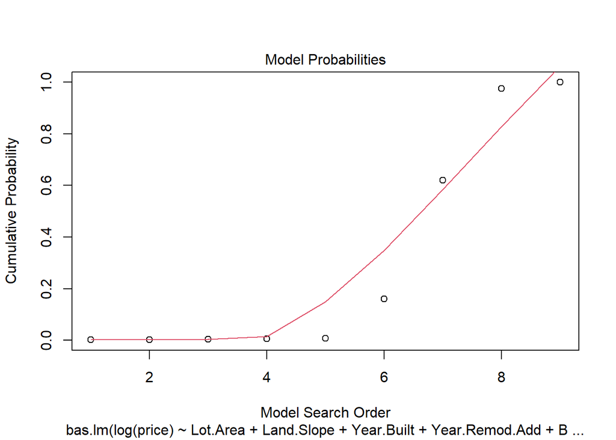

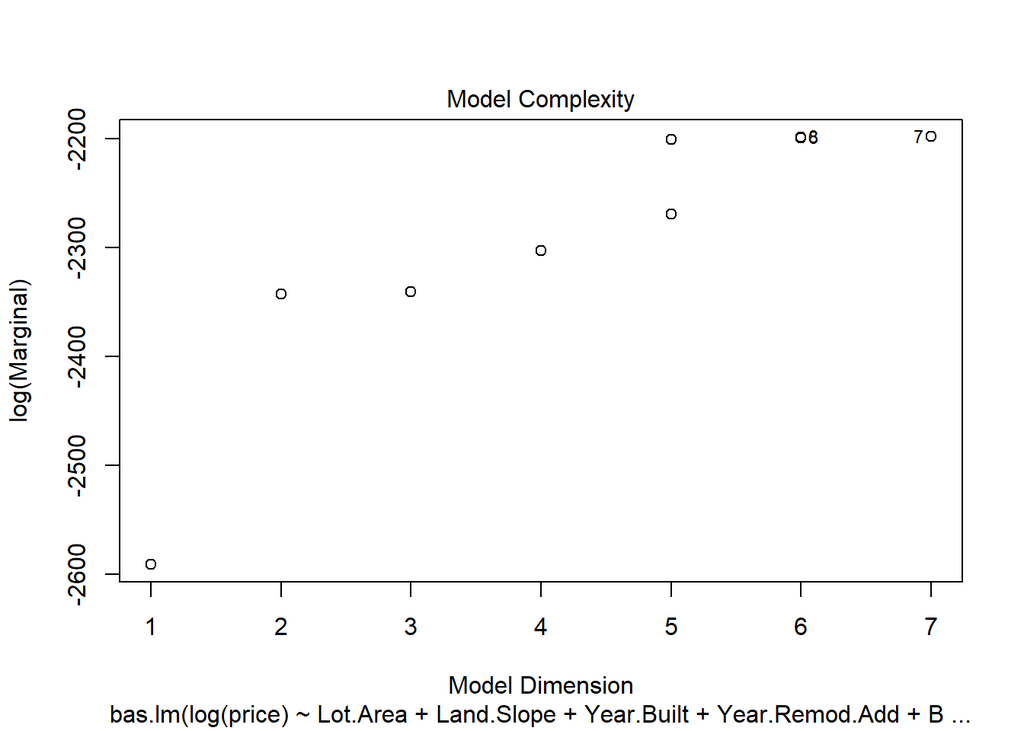

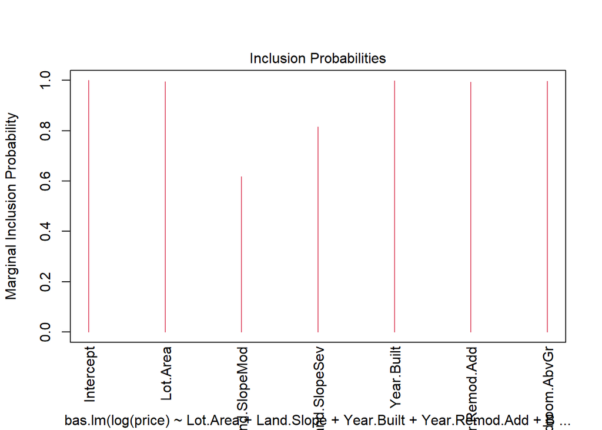

```r
plot(fit_bic)
```

```r
ames_train$res_sqr <- fit_lm$residuals**2
which(ames_train$res_sqr == max(ames_train$res_sqr))
```

```
## 428
## 428
```

```r
exp(fit_lm$fitted.values[428])
```

```
##      428
## 103176.2
```

By comparing the residuals on the plot, we found that house # 428 (PID 902207130) looks like an outlier, which tells us that it has the largest squared residual. The chart shows that the lot does not fit the model. This can be explained by the lowest price of the house and the year it was built. It sold for just over $ 12,000. The target price is $ 103,176.20 making it a significant variance. It has an unfinished basement and was sold in abnormal conditions. Both variables are not included in our model. This seems to be the most likely explanation for the low selling price.

6. Use the same model selection method you chose in Question 4 to again find the best multiple regression model to predict the natural log of home prices, but this time **replacing Lot.Area with log(Lot.Area)**. Do you arrive at a model including the same set of predictors?

```r
fit_lm_log = lm(log(price) ~ log(Lot.Area) + Land.Slope + Year.Built + Year.Remod.Add + Bedroom.AbvGr,
            data = ames_train)
summary(fit_lm_log)
```

```
##
## Call:
## lm(formula = log(price) ~ log(Lot.Area) + Land.Slope + Year.Built +
##     Year.Remod.Add + Bedroom.AbvGr, data = ames_train)
##
## Residuals:
##      Min       1Q   Median       3Q      Max
## -2.14050 -0.15650 -0.01561  0.15350  0.90854
##
## Coefficients:
##                  Estimate Std. Error t value Pr(>|t|)
## (Intercept)    -1.553e+01  8.197e-01 -18.947  < 2e-16 ***
## log(Lot.Area)   2.442e-01  1.708e-02  14.297  < 2e-16 ***
## Land.SlopeMod   1.151e-01  4.734e-02   2.431   0.0152 *
## Land.SlopeSev  -6.554e-02  1.222e-01  -0.536   0.5917
## Year.Built      5.981e-03  3.597e-04  16.628  < 2e-16 ***
## Year.Remod.Add  6.734e-03  5.190e-04  12.975  < 2e-16 ***
## Bedroom.AbvGr   5.909e-02  1.055e-02   5.599  2.8e-08 ***
## ---
## Signif. codes:  0 '***' 0.001 '**' 0.01 '*' 0.05 '.' 0.1 ' ' 1
##
## Residual standard error: 0.2649 on 993 degrees of freedom
## Multiple R-squared:  0.6056, Adjusted R-squared:  0.6032
## F-statistic: 254.1 on 6 and 993 DF,  p-value: < 2.2e-16
```

```r
fit_bic_log = bas.lm(log(price) ~ log(Lot.Area) + Land.Slope + Year.Built + Year.Remod.Add + Bedroom.AbvGr,
        data = ames_train,
        prior = "BIC",
        modelprior = uniform(),
        method = "MCMC" )
summary(fit_bic_log)
```

```
##                P(B != 0 | Y)    model 1       model 2       model 3
## Intercept         1.00000000     1.0000     1.0000000  1.000000e+00
## log(Lot.Area)     0.98671875     1.0000     1.0000000  1.000000e+00
## Land.SlopeMod     0.41015625     0.0000     1.0000000  0.000000e+00
## Land.SlopeSev     0.03984375     0.0000     0.0000000  1.000000e+00
## Year.Built        0.99765625     1.0000     1.0000000  1.000000e+00
## Year.Remod.Add    0.97812500     1.0000     1.0000000  1.000000e+00
## Bedroom.AbvGr     0.96484375     1.0000     1.0000000  1.000000e+00
## BF                        NA     1.0000     0.6494644  3.866294e-02
## PostProbs                 NA     0.5121     0.3880000  2.650000e-02
## R2                        NA     0.6031     0.6055000  6.032000e-01
## dim                       NA     5.0000     6.0000000  6.000000e+00
## logmarg                   NA -2142.5652 -2142.9968106 -2.145818e+03
##                      model 4       model 5
## Intercept       1.000000e+00  1.000000e+00
## log(Lot.Area)   1.000000e+00  1.000000e+00
## Land.SlopeMod   0.000000e+00  0.000000e+00
## Land.SlopeSev   0.000000e+00  0.000000e+00
## Year.Built      1.000000e+00  1.000000e+00
## Year.Remod.Add  1.000000e+00  0.000000e+00
## Bedroom.AbvGr   0.000000e+00  1.000000e+00
## BF              1.412793e-05  2.253065e-33
## PostProbs       2.580000e-02  1.640000e-02
## R2              5.913000e-01  5.355000e-01
## dim             4.000000e+00  4.000000e+00
## logmarg        -2.153733e+03 -2.217738e+03
```

By replacing Lot.Area with log(Lot.Area), the algorithm arrives at a different model, where Lan.Slope is excluded and only 4 variables are considered in the model.

7. Do you think it is better to log transform Lot.Area, in terms of assumptions for linear regression? Make graphs of the predicted values of log home price versus the true values of log home price for the regression models selected for Lot.Area and log(Lot.Area). Referencing these two plots, provide a written support that includes a quantitative justification for your answer in the first part of question 7.

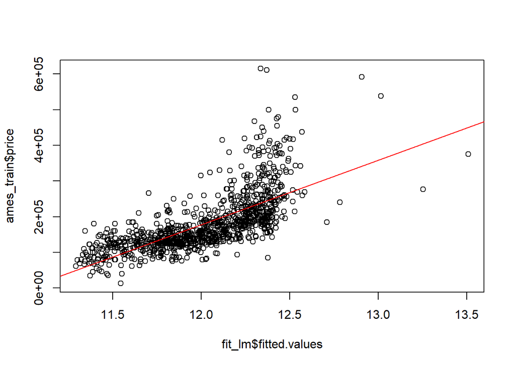

```r
plot(ames_train$price~fit_lm$fitted.values)
abline(lm(ames_train$price~fit_lm$fitted.values), col="red")
```

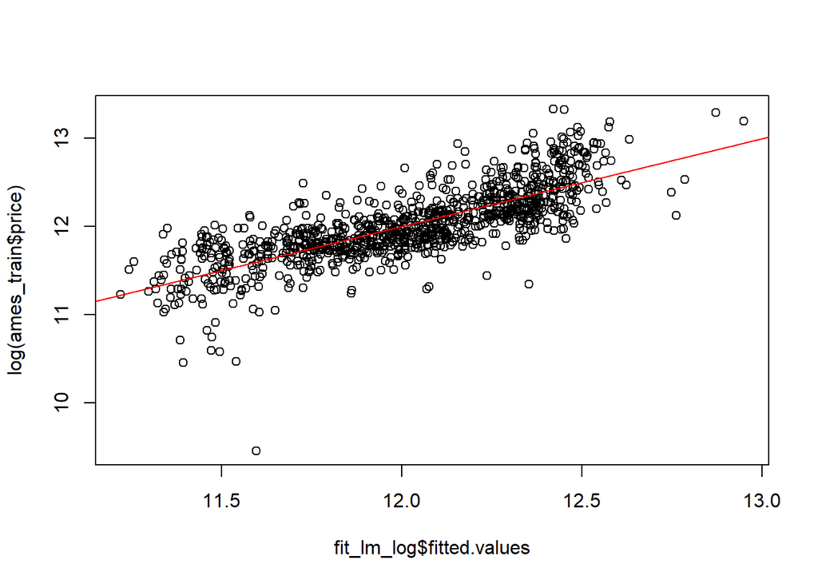

```r
plot(log(ames_train$price)~fit_lm_log$fitted.values)
abline(lm(log(ames_train$price)~fit_lm_log$fitted.values), col="red")
```